# Soluciones 4

Sergio Camiz

2025-05-18

```r
options(width = 300)                                        # ancho de página
```

## 1 Construir una carpeta Ejercicio_4

*Hecho*

*Se define también la función que incluye los intervalos de confianza en el summary de los modelos.*

```r
setwd("/Work/Lavoro/PUCP/Corso PUCP 2025 - Modelo Lineal/Lezioni 2025/Clase_4 - Propiedades estadísticas/Esercizi")                            # carpeta de trabajo
```

## 2 Cargar desde Paideia:

```
  Decathlon.csv
y colocarlo en Rstudio como siempre
```

```r
dat                 <- read.csv("Decathlon.csv",row.names=1) # archivo datos
head(dat)
```

```
##           X100m Long.jump Shot.put High.jump X400m X110m.hurdle Discus Pole.vault Javeline X1500m Points
## Sebrle    10.85      7.84    16.36      2.12 48.36        14.05  48.72        5.0    70.52 280.01   8893
## Clay      10.44      7.96    15.23      2.06 49.19        14.13  50.11        4.9    69.71 282.00   8820
## Karpov    10.50      7.81    15.93      2.09 46.81        13.97  51.65        4.6    55.54 278.11   8725
## Macey     10.89      7.47    15.73      2.15 48.97        14.56  48.34        4.4    58.46 265.42   8414
## Warners   10.62      7.74    14.48      1.97 47.97        14.01  43.73        4.9    55.39 278.05   8343
## Zsivoczky 10.91      7.14    15.31      2.12 49.40        14.95  45.62        4.7    63.45 269.54   8287
```

```r
str(dat)
```

```
## 'data.frame':    28 obs. of  11 variables:
##  $ X100m       : num  10.8 10.4 10.5 10.9 10.6 ...
##  $ Long.jump   : num  7.84 7.96 7.81 7.47 7.74 7.14 7.19 7.53 7.48 7.49 ...
##  $ Shot.put    : num  16.4 15.2 15.9 15.7 14.5 ...
##  $ High.jump   : num  2.12 2.06 2.09 2.15 1.97 2.12 2.03 1.88 2.12 1.94 ...
##  $ X400m       : num  48.4 49.2 46.8 49 48 ...
##  $ X110m.hurdle: num  14.1 14.1 14 14.6 14 ...
##  $ Discus      : num  48.7 50.1 51.6 48.3 43.7 ...
##  $ Pole.vault  : num  5 4.9 4.6 4.4 4.9 4.7 4.8 5.4 4.4 5.1 ...
##  $ Javeline    : num  70.5 69.7 55.5 58.5 55.4 ...
##  $ X1500m      : num  280 282 278 265 278 ...
##  $ Points      : int  8893 8820 8725 8414 8343 8287 8237 8235 8225 8102 ...
```

```r
nom                 <- rownames(dat)
```

## 3 Decathlon: modelar “Points”

con las cuatro velocidades,

```r
attach(dat)
lm1                 <- lm(Points~X100m+X400m+X110m.hurdle+X1500m,data=dat)
summary(lm1)
```

```
##
## Call:
## lm(formula = Points ~ X100m + X400m + X110m.hurdle + X1500m,
##     data = dat)
##
## Residuals:
##     Min      1Q  Median      3Q     Max
## -385.70 -130.47   11.36   90.89  577.64
##
## Coefficients:
##               Estimate Std. Error t value Pr(>|t|)
## (Intercept)  22844.243   2329.638   9.806 1.11e-09 ***
## X100m         -596.689    291.082  -2.050   0.0519 .
## X400m          -83.775     62.117  -1.349   0.1906
## X110m.hurdle  -247.309    123.978  -1.995   0.0580 .
## X1500m          -1.888      5.268  -0.358   0.7233
## ---
## Signif. codes:  0 '***' 0.001 '**' 0.01 '*' 0.05 '.' 0.1 ' ' 1
##
## Residual standard error: 230.6 on 23 degrees of freedom
## Multiple R-squared:  0.6736, Adjusted R-squared:  0.6168
## F-statistic: 11.86 on 4 and 23 DF,  p-value: 2.242e-05
```

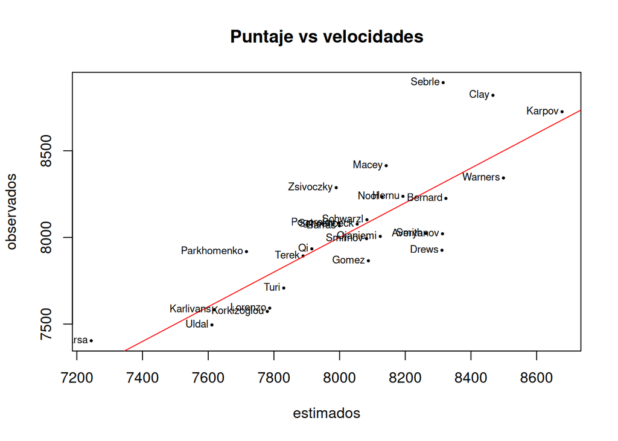

```r
plot(lm1$fitted.values,Points, main="Puntaje vs velocidades",
     xlab ="estimados",ylab="observados",pch=20,cex=0.5)
  abline(0,1,col="red")
  text(lm1$fitted.values,Points,lab=nom,cex=0.7,pos=2,off=.2)
```

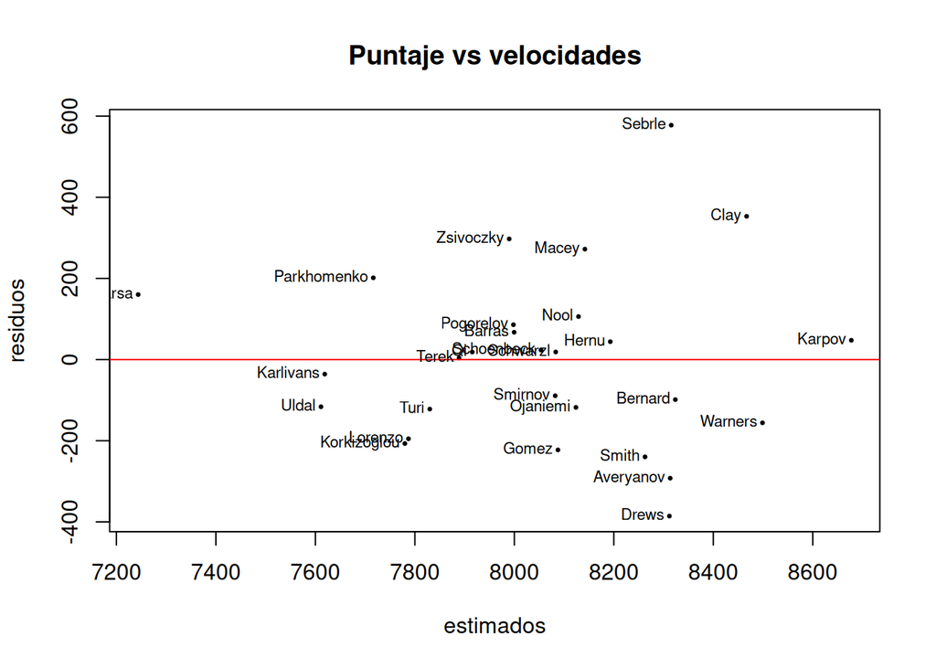

```r
plot(lm1$fitted.values,lm1$residuals, main="Puntaje vs velocidades",
     xlab ="estimados",ylab="residuos",pch=20,cex=0.5)
  abline(h=0,col="red")
  text(lm1$fitted.values,lm1$residuals,lab=nom,cex=0.7,pos=2,off=.2)
```

luego con los tres saltos

```r
lm2                 <- lm(Points~Long.jump+High.jump+Pole.vault,data=dat)
summary(lm2)
```

```
##
## Call:
## lm(formula = Points ~ Long.jump + High.jump + Pole.vault, data = dat)
##
## Residuals:
##     Min      1Q  Median      3Q     Max
## -412.58 -112.84  -21.79  131.11  472.48
##
## Coefficients:
##             Estimate Std. Error t value Pr(>|t|)
## (Intercept)   -919.8     1113.6  -0.826 0.416956
## Long.jump      632.9      124.1   5.099 3.24e-05 ***
## High.jump     1791.4      451.7   3.966 0.000574 ***
## Pole.vault     175.9      137.4   1.280 0.212895
## ---
## Signif. codes:  0 '***' 0.001 '**' 0.01 '*' 0.05 '.' 0.1 ' ' 1
##
## Residual standard error: 195.6 on 24 degrees of freedom
## Multiple R-squared:  0.7549, Adjusted R-squared:  0.7243
## F-statistic: 24.64 on 3 and 24 DF,  p-value: 1.665e-07
```

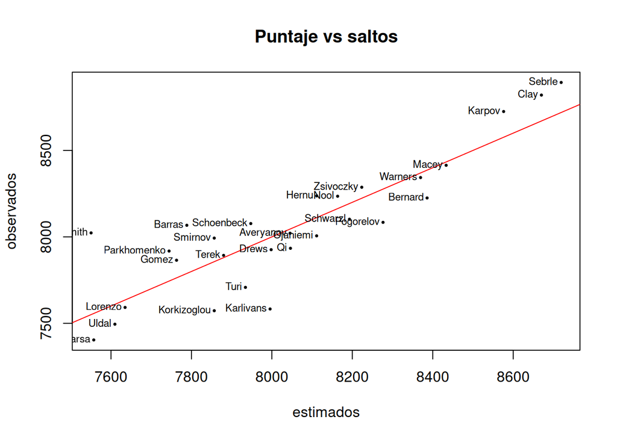

```r
plot(lm2$fitted.values,Points, main="Puntaje vs saltos",
     xlab ="estimados",ylab="observados",pch=20,cex=0.5)
  abline(0,1,col="red")
  text(lm2$fitted.values,Points,lab=nom,cex=0.7,pos=2,off=.2)
```

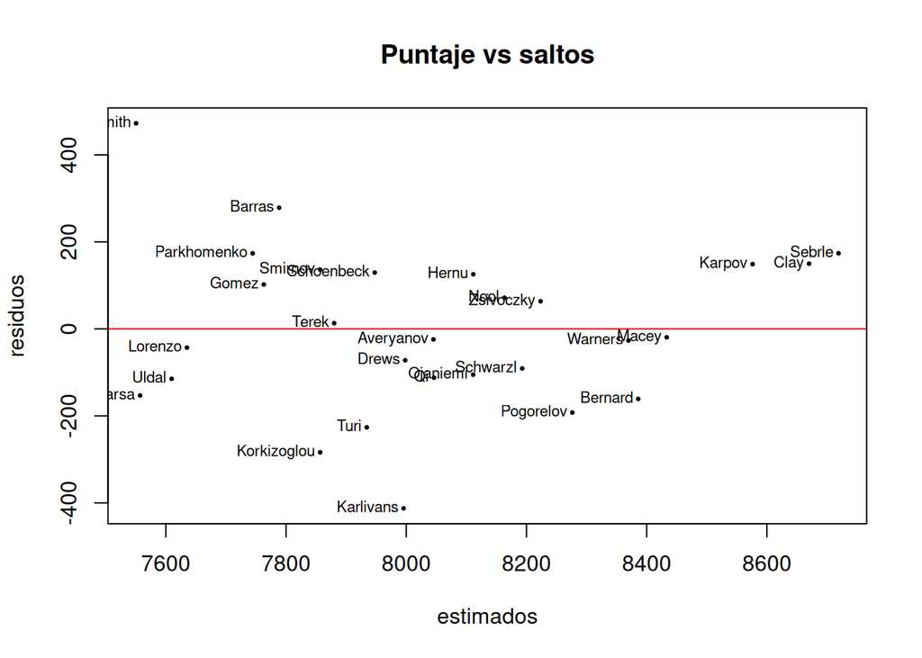

```r
plot(lm2$fitted.values,lm2$residuals, main="Puntaje vs saltos",
     xlab ="estimados",ylab="residuos",pch=20,cex=0.5)
  abline(h=0,col="red")
  text(lm2$fitted.values,lm2$residuals,lab=nom,cex=0.7,pos=2,off=.2)
```

y luego con los tres lanzamientos.

```r
lm3                 <- lm(Points~Shot.put+Discus+Javeline,data=dat)
summary(lm3)
```

```
##
## Call:
## lm(formula = Points ~ Shot.put + Discus + Javeline, data = dat)
##
## Residuals:
##     Min      1Q  Median      3Q     Max
## -777.19 -137.44   20.18  206.08  387.86
##
## Coefficients:
##             Estimate Std. Error t value Pr(>|t|)
## (Intercept)  3547.75    1039.03   3.414  0.00228 **
## Shot.put      186.40      93.25   1.999  0.05706 .
## Discus         18.66      23.11   0.807  0.42731
## Javeline       16.11      12.38   1.301  0.20569
## ---
## Signif. codes:  0 '***' 0.001 '**' 0.01 '*' 0.05 '.' 0.1 ' ' 1
##
## Residual standard error: 295.7 on 24 degrees of freedom
## Multiple R-squared:  0.4401, Adjusted R-squared:  0.3702
## F-statistic: 6.289 on 3 and 24 DF,  p-value: 0.002654
```

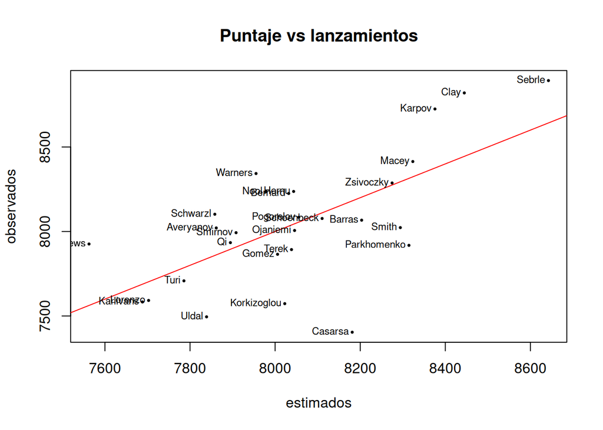

```r
plot(lm3$fitted.values,Points, main="Puntaje vs lanzamientos",
     xlab ="estimados",ylab="observados",pch=20,cex=0.5)
  abline(0,1,col="red")
  text(lm3$fitted.values,Points,lab=nom,cex=0.7,pos=2,off=.2)
```

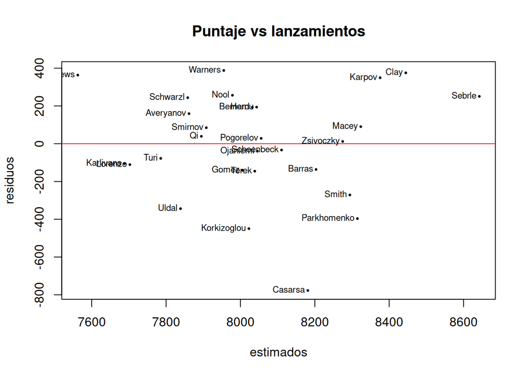

```r
plot(lm3$fitted.values,lm3$residuals, main="Puntaje vs lanzamientos",
     xlab ="estimados",ylab="residuos",pch=20,cex=0.5)
  abline(h=0,col="red")
  text(lm3$fitted.values,lm3$residuals,lab=nom,cex=0.7,pos=2,off=.2)
```

Por cada modelo salir el summary y dibujar también los gráficos de valores observados contra esperados y de residuos contra esperados.

## 4 Evaluar si el modelo tiene sentido

(Estadística F, umbral 5%) y si todas las variables explicativas tienen sentido (t de student, umbral 5%).

### 4.1 *Modelo velocidades*

*El modelo tiene sentido, ya que la F tiene una probabilidad asociada del orden de $10^{-5}$. El $R^2=.67$ indica una buena capacidad explicativa, mientras que los 400m y 1500m no son significativos a nivel de $5\%$ y los demás se encuentran a penas arriba de este umbral. Probablemente se trata de exceso de correlación entre las velocidades. El alfa es fuertemente significativo, coerentemente con el hecho que tiempo zero en las pruebas sería un puntaje infinido.*

### 4.2 *Modelo saltos*

*El modelo tiene sentido, ya que la F tiene una probabilidad asociada del orden de $10^{-7}$. El $R^2=.75$ indica una muy buena capacidad explicativa, con solo saltos en alto y en largo siendo significativo, mientras el con la garrocha no. Se podría intentar de reducir el modelo solo a dos saltos. El alfa no es significativo, como debería ser.*

### 4.3 *Modelo lanzamientos*

*El modelo tiene sentido, ya que la F tiene una probabilidad asociada de $0.00266$. El $R^2=.44$ indica una capacidad explicativa media, inclusivo que solo el lanzamiento del peso es a penas arriba del umbral de $5\%$. Se podría intentar de reducir este modelo también. El alfa significativose resulta raro.*

## 5 Considerando el resíduo promedio (Residual standard error), ¿cual modelo le parece mejor?

*Con referencia al mismo Puntaje el residuo promedio si se puede comparar. Se resultan los siguientes:*

```r
cat(paste("\n Velocidades:  MSe =",summary(lm1)$sigma,"\n"))
```

```
##
##  Velocidades:  MSe = 230.638565637828
```

```r
cat(paste(" Saltos:       MSe =",summary(lm2)$sigma,"\n"))
```

```
##  Saltos:       MSe = 195.638675285607
```

```r
cat(paste(" Lanzamientos: MSe =",summary(lm3)$sigma,"\n"))
```

```
##  Lanzamientos: MSe = 295.682041259315
```

*El modelo con saltos se resulta sin embargo el mejor.*

## 6 Empleando los símbolos

para los modelos, intentar también de modelar según las siguientes fórmulas: points = a + b 100m + c Javeline² + d (Shot_put x 400m)

```r
lm4                 <- lm(Points~X100m + I(Javeline^2) + Shot.put:X400m,data=dat)
summary(lm4)
```

```
##
## Call:
## lm(formula = Points ~ X100m + I(Javeline^2) + Shot.put:X400m,
##     data = dat)
##
## Residuals:
##     Min      1Q  Median      3Q     Max
## -405.87 -152.48   20.91  125.97  357.30
##
## Coefficients:
##                  Estimate Std. Error t value Pr(>|t|)
## (Intercept)     1.881e+04  2.172e+03   8.661 7.53e-09 ***
## X100m          -1.121e+03  1.822e+02  -6.152 2.35e-06 ***
## I(Javeline^2)   2.391e-01  7.513e-02   3.182  0.00401 **
## Shot.put:X400m  8.819e-01  1.058e+00   0.834  0.41264
## ---
## Signif. codes:  0 '***' 0.001 '**' 0.01 '*' 0.05 '.' 0.1 ' ' 1
##
## Residual standard error: 217.9 on 24 degrees of freedom
## Multiple R-squared:  0.6958, Adjusted R-squared:  0.6578
## F-statistic:  18.3 on 3 and 24 DF,  p-value: 2.142e-06
```

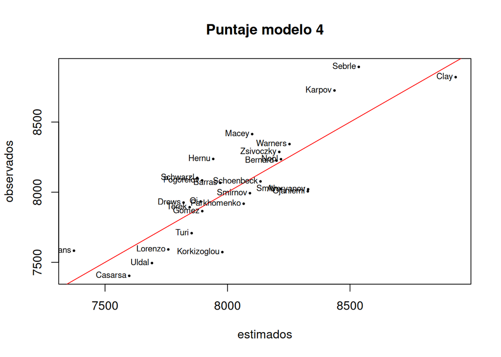

```r
plot(lm4$fitted.values,dat$Points, main="Puntaje modelo 4",
     xlab ="estimados",ylab="observados",pch=20,cex=0.5)
  abline(0,1,col="red")
  text(lm4$fitted.values,dat$Points,lab=nom,cex=0.7,pos=2,off=.2)
```

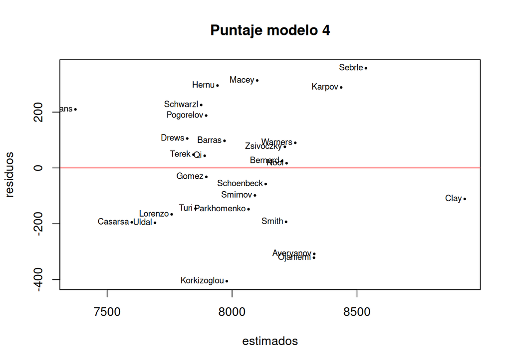

```r
plot(lm4$fitted.values,lm4$residuals, main="Puntaje modelo 4",
     xlab ="estimados",ylab="residuos",pch=20,cex=0.5)
  abline(h=0,col="red")
  text(lm4$fitted.values,lm4$residuals,lab=nom,cex=0.7,pos=2,off=.2)
```

```
points = a + b  1500m + Discus + 1500m x Discus + log(Long_jump)
```

proporcionando los resultados y los gráficos.

```r
lm5                 <- lm(Points~Discus*X1500m + I(log(Long.jump)),data=dat)
summary(lm5)
```

```
##
## Call:
## lm(formula = Points ~ Discus * X1500m + I(log(Long.jump)), data = dat)
##
## Residuals:
##     Min      1Q  Median      3Q     Max
## -432.68  -43.01   -7.61   91.44  418.47
##
## Coefficients:
##                     Estimate Std. Error t value Pr(>|t|)
## (Intercept)       -28075.826  16483.576  -1.703   0.1020
## Discus               645.765    363.550   1.776   0.0889 .
## X1500m                88.195     59.426   1.484   0.1514
## I(log(Long.jump))   4841.296    802.624   6.032 3.76e-06 ***
## Discus:X1500m         -2.159      1.312  -1.646   0.1134
## ---
## Signif. codes:  0 '***' 0.001 '**' 0.01 '*' 0.05 '.' 0.1 ' ' 1
##
## Residual standard error: 185.5 on 23 degrees of freedom
## Multiple R-squared:  0.7888, Adjusted R-squared:  0.7521
## F-statistic: 21.48 on 4 and 23 DF,  p-value: 1.725e-07
```

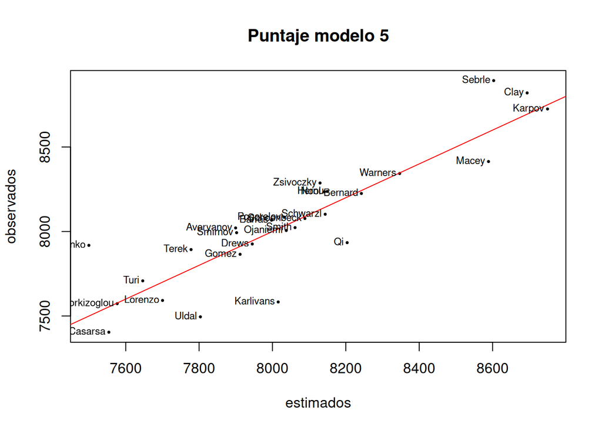

```r
plot(lm5$fitted.values,dat$Points, main="Puntaje modelo 5",
     xlab ="estimados",ylab="observados",pch=20,cex=0.5)
  abline(0,1,col="red")
  text(lm5$fitted.values,dat$Points,lab=nom,cex=0.7,pos=2,off=.2)
```

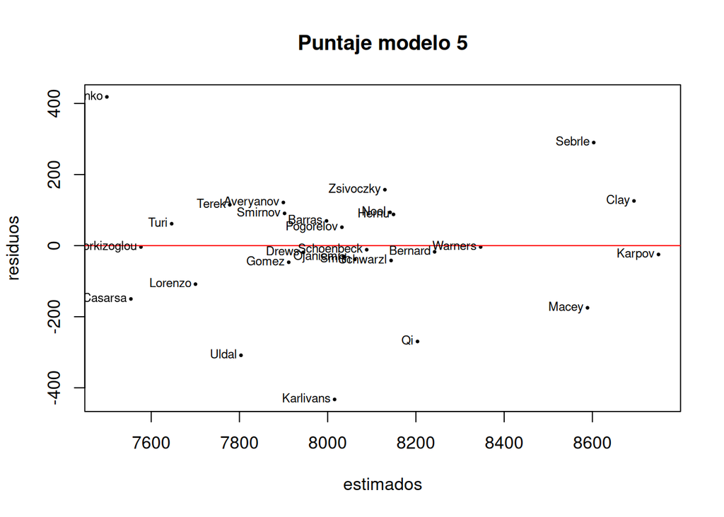

```r
plot(lm5$fitted.values,lm5$residuals, main="Puntaje modelo 5",
     xlab ="estimados",ylab="residuos",pch=20,cex=0.5)
  abline(h=0,col="red")
  text(lm5$fitted.values,lm5$residuals,lab=nom,cex=0.7,pos=2,off=.2)
```

```r
detach(dat)
```

*Esto modelo aún tampoco tenga sentido como concepción, se resulta muy bueno, con un $R^2=0.79$ y una F muy significativa. Por otro lado ni los 1500 metros ni su interacción con el lanzamiento del disco se resultan significativos.*

## 7 intentar de escribir un reportito,

disfrutando a las propiedades de Rmarkdown, comentando los resultados y una evaluación de ellos.

## 8 *Modelos lineales sobre Decathlon*

*Los datos de Decathlon se refieren a 28 atletas que participaron a la competición de Decathlon a las Olimpiades de Paris 2004. De ellos se tiene el resultado en cada una especialidad y el puntaje conseguido.*

*Se conocen las fórmulas que proporcionan el puntaje bajo los resultados, que presentan non linearidad, pero se quiere igualmente estimar unos modelos lineals para ver si y hasta que nivel se puede hacer una estimación del puntaje a través de un modelo lineal.*

*En en este reporte limitamos la atención a tres modelos construidos respectivamente considerando los tres grupos de especialidades homogéneas: cuatro velocidades, tres saltos y tres lanzamientos.*

### 8.1 *Modelo velocidades*

*En este modelo se emplean 100 metros, 400 metros, 110 metros obstáculos y 1500 metros. Los resultados son los siguientes:*

```
##
##  Resultados del modelo Puntaje con velocidades
```

```
##
## Call:
## lm(formula = Points ~ X100m + X400m + X110m.hurdle + X1500m,
##     data = dat)
##
## Residuals:
##     Min      1Q  Median      3Q     Max
## -385.70 -130.47   11.36   90.89  577.64
##
## Coefficients:
##                            2.5 %    97.5 % Std. Error t value Pr(>|t|)
## (Intercept)  22844.243 18025.019 27663.467   2329.638   9.806 1.11e-09 ***
## X100m         -596.689 -1198.839     5.461    291.082  -2.050   0.0519 .
## X400m          -83.775  -212.273    44.723     62.117  -1.349   0.1906
## X110m.hurdle  -247.309  -503.777     9.159    123.978  -1.995   0.0580 .
## X1500m          -1.888   -12.786     9.009      5.268  -0.358   0.7233
## ---
## Signif. codes:  0 '***' 0.001 '**' 0.01 '*' 0.05 '.' 0.1 ' ' 1
##
## Residual standard error: 230.6 on 23 degrees of freedom
## Multiple R-squared:  0.6736, Adjusted R-squared:  0.6168
## F-statistic: 11.86 on 4 and 23 DF,  p-value: 2.242e-05
```

*se resulta un modelo fiable, ya que la estadística $F$ tiene una probabilidad asociada del orden de $10^{-5}$. El $R^2=.67$ indica una buena capacidad explicativa. Los coeficientes negativos de todas las especialidades indican que el puntaje aumenta con la disminución del tiempo, pero ningún parámetro es significativo sino el alfa. De los demás, 100 metros y 110 metros obstáculos tienen una probabilidad de poco mayor de $5\%$ mientras los 400m y 1500m no aparecen relevantes.*

```
##
##  Matriz de correlación entre velocidades
```

```
##                   X100m     X400m X110m.hurdle     X1500m
## X100m        1.00000000 0.6347852    0.5425579 0.05843441
## X400m        0.63478518 1.0000000    0.5198805 0.55122370
## X110m.hurdle 0.54255793 0.5198805    1.0000000 0.17904538
## X1500m       0.05843441 0.5512237    0.1790454 1.00000000
```

*La correlaciṕn entre 100 metros y los demás (a parte 1500 metros) podría explicar este resultado. Probablemente se trata de exceso de correlación entre las velocidades. El alfa es fuertemente significativo, coerentemente con el hecho que tiempo zero en las pruebas sería un puntaje infinido.*

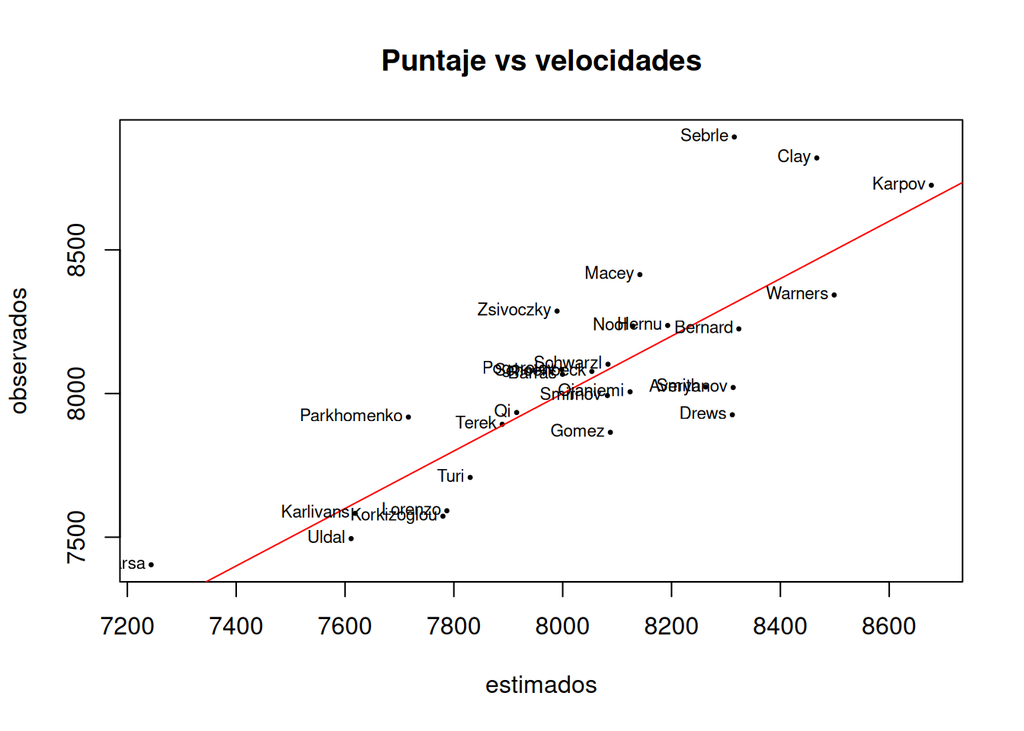

*El gráfico estimados observados muestra un patrón de atletas alrededor de la recta de ajuste óptimo, sino que se resultan Sebrle y Clay, los mejores fuertemente bajo-estimados.*

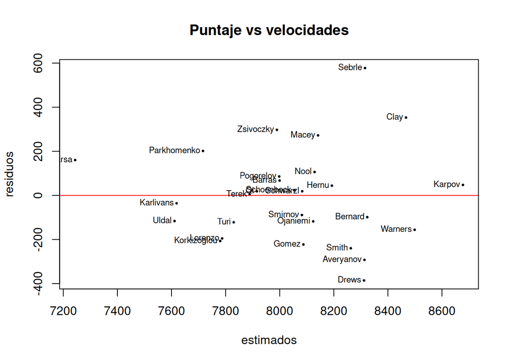

*En el gráfico de los residuos se ve que Sebrle tiene un residuo muy fuerte, pero también hay también atletads sobre-estimados, como Drews.*

### 8.2 *Modelo saltos*

*En este modelo se están empleando saltos en largo, en alto y con garrocha. Los resultados son los siguientes:*

```r
sum.lm(lm2)
```

```
##
## Call:
## lm(formula = Points ~ Long.jump + High.jump + Pole.vault, data = dat)
##
## Residuals:
##     Min      1Q  Median      3Q     Max
## -412.58 -112.84  -21.79  131.11  472.48
##
## Coefficients:
##                       2.5 %  97.5 % Std. Error t value Pr(>|t|)
## (Intercept)  -919.8 -3218.0  1378.5     1113.6  -0.826 0.416956
## Long.jump     632.9   376.7   889.1      124.1   5.099 3.24e-05 ***
## High.jump    1791.4   859.2  2723.6      451.7   3.966 0.000574 ***
## Pole.vault    175.9  -107.8   459.5      137.4   1.280 0.212895
## ---
## Signif. codes:  0 '***' 0.001 '**' 0.01 '*' 0.05 '.' 0.1 ' ' 1
##
## Residual standard error: 195.6 on 24 degrees of freedom
## Multiple R-squared:  0.7549, Adjusted R-squared:  0.7243
## F-statistic: 24.64 on 3 and 24 DF,  p-value: 1.665e-07
```

*Este modelo aparece estimar el puntaje mejor del primero, ya que su F tiene una probabilidad asociada del orden de $10^{-7}$ y su $R^2=.75$ indica una muy buena capacidad explicativa. Por otro lado, solo los parámetros de saltos en alto y en largo resultan significativos, mientras lo del salto con garrocha no. Por otro lado, el alfa no es significativo, como justamente debería ser.*

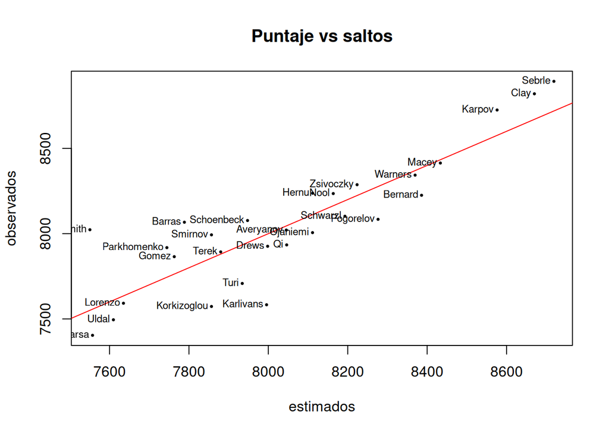

```r
plot(lm2$fitted.values,dat$Points, main="Puntaje vs saltos",
     xlab ="estimados",ylab="observados",pch=20,cex=0.5)
  abline(0,1,col="red")
  text(lm2$fitted.values,dat$Points,lab=nom,cex=0.7,pos=2,off=.2)
```

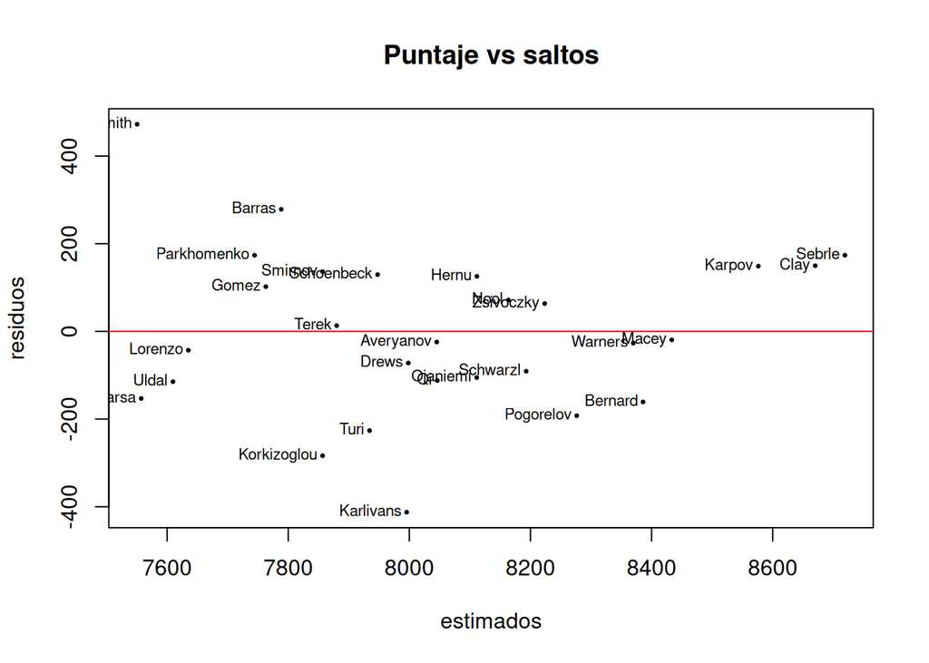

```r
plot(lm2$fitted.values,lm2$residuals, main="Puntaje vs saltos",
     xlab ="estimados",ylab="residuos",pch=20,cex=0.5)
  abline(h=0,col="red")
  text(lm2$fitted.values,lm2$residuals,lab=nom,cex=0.7,pos=2,off=.2)
```

y luego con los tres lanzamientos.

```r
lm3                 <- lm(Points~Shot.put+Discus+Javeline,data=dat)
sum.lm(lm3)
```

```
##
## Call:
## lm(formula = Points ~ Shot.put + Discus + Javeline, data = dat)
##
## Residuals:
##     Min      1Q  Median      3Q     Max
## -777.19 -137.44   20.18  206.08  387.86
##
## Coefficients:
##                         2.5 %   97.5 % Std. Error t value Pr(>|t|)
## (Intercept) 3547.750 1403.297 5692.203   1039.030   3.414  0.00228 **
## Shot.put     186.403   -6.060  378.867     93.252   1.999  0.05706 .
## Discus        18.664  -29.039   66.366     23.113   0.807  0.42731
## Javeline      16.106   -9.449   41.661     12.382   1.301  0.20569
## ---
## Signif. codes:  0 '***' 0.001 '**' 0.01 '*' 0.05 '.' 0.1 ' ' 1
##
## Residual standard error: 295.7 on 24 degrees of freedom
## Multiple R-squared:  0.4401, Adjusted R-squared:  0.3702
## F-statistic: 6.289 on 3 and 24 DF,  p-value: 0.002654
```

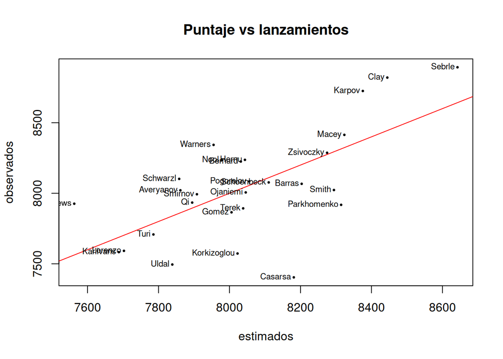

```r
plot(lm3$fitted.values,dat$Points, main="Puntaje vs lanzamientos",
     xlab ="estimados",ylab="observados",pch=20,cex=0.5)
  abline(0,1,col="red")
  text(lm3$fitted.values,dat$Points,lab=nom,cex=0.7,pos=2,off=.2)
```

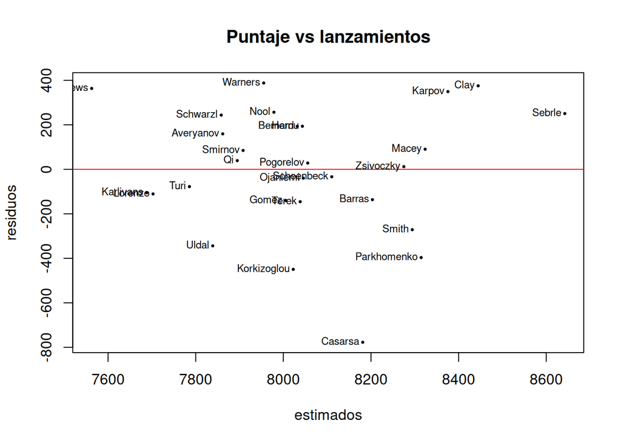

```r
plot(lm3$fitted.values,lm3$residuals, main="Puntaje vs lanzamientos",
     xlab ="estimados",ylab="residuos",pch=20,cex=0.5)
  abline(h=0,col="red")
  text(lm3$fitted.values,lm3$residuals,lab=nom,cex=0.7,pos=2,off=.2)
```

Por cada modelo salir el summary y dibujar también los gráficos de valores observados contra esperados y de residuos contra esperados.

## 9 Evaluar si el modelo tiene sentido

(Estadística F, umbral 5%) y si todas las variables explicativas tienen sentido (t de student, umbral 5%).

### 9.1 *Modelo lanzamientos*

*El modelo tiene sentido, ya que la F tiene una probabilidad asociada de $0.00266$. El $R^2=.44$ indica una capacidad explicativa media, inclusivo que solo el lanzamiento del peso es a penas arriba del umbral de $5\%$. Se podría intentar de reducir este modelo también. El alfa significativose resulta raro.*

## 10 Considerando el resíduo promedio (Residual standard error), ¿cual modelo le parece mejor?

*Con referencia al mismo Puntaje el residuo promedio si se puede comparar. Se resultan los siguientes:*

```r
cat(paste("\n Velocidades:  MSe =",summary(lm1)$sigma,"\n"))
```

```
##
##  Velocidades:  MSe = 230.638565637828
```

```r
cat(paste(" Saltos:       MSe =",summary(lm2)$sigma,"\n"))
```

```
##  Saltos:       MSe = 195.638675285607
```

```r
cat(paste(" Lanzamientos: MSe =",summary(lm3)$sigma,"\n"))
```

```
##  Lanzamientos: MSe = 295.682041259315
```

*El modelo con saltos se resulta sin embargo el mejor.*

## 11 guardar los archivos

.Rmd y .html y enviar-los a sergio@camiz.it dentro del 30 de Abril a las 23:59.